# edld_654_final_project_MC

Michelle Cui

2025-11-10

- **Research problem (10pts)**: Describe the task you want to achieve. What is the outcome of interest? What are you trying to predict? Why is it important? What are the potential benefits of having a predictive model for this outcome?
- **Description of the data (15pts)**: Describe core features of the data, any additional features you produced from existing features and how, basic descriptive statistics about these features, and any missing data analysis you conduct. The description should be sufficiently clear that the instructor understands all the variables included in your modeling.

The main objective of this task is to explore several supervised learning models for predicting the outcome of interest. The Dataset I used is the US teacher questionnaire survey data provided in the International Computer and Information Literacy Study(ICILS) 2023.

Which teacher-level factors predict how frequently teachers have 8-th grade students write computer programs, games, or apps during classroom instruction? Whether teacher-level factors can predict how frequently teachers have 8-th grade students write computer programs, games, or apps during classroom instruction?

The ICILS is designed to measure 8th-grade students’ capabilities to use Computer Information Literacy(CIL) and Computational Thinking(CT). Along with 35 education systems, United States participated CIL assessment and CT assessment with 24 education systems. The study survey included context questionnaire for school principles & coordinators, teachers, and 8th-grade students. It is to my interest that, the study didn’t include the U.S. teacher data in the international average or presented in the main ICILS 2023 international report because the response rate for sampled teachers in the United States was below 50 percent. The correlated factors could be varied. Thus, I plan to use this dataset to explore more about teachers’ usage of ICT in the U.S.

- **Description of the models (15pts)**: Apply at least three different modeling approaches to predict the outcome in the dataset. Describe any specific setting used during the model fitting (e.g., hyperparameter tuning, cross-validation). Also, discuss how you plan to evaluate model performance.
- **Model fit (20pts)**: Provide the results of your model evaluation. Compare and contrasts results from different modeling approaches, including a discussion of model performance. Discuss your final model selection and the evidence that led you to this selection. If it is a classification problem, how did you choose a cut-off point for binary predictions? Did you consider different cut-off points?
- **Data visualization (5pts)**: Include at least two plots (or more) to help communicate your findings. The plots may be of initial data explorations, fits of individual models, and plots displaying the performance of competing models.
- **Discussion/Conclusion (25pts)**: Discuss and summarize what you learned. Which variables were the most important in predicting your outcome? Was this expected or surprising? Were different models close in performance, or were there significant gaps in performance from different modeling approaches? Are there practical/applied findings that could help the field of your interest based on your work? If yes, what are they?

Should I use multinomial regression?

- **Reproducibility (10pts)**: Provide a link to the GitHub repo at the beginning of your report as a note.

## 1. Initial Data Preparation

```r
load(here("data","BTGUSAI3.Rdata"))
teacher <- BTGUSAI3
```

```r
vars_to_remove <-grep(
  pattern = "^(TRWGT|WGT|JKZONET|JKREPT|SENWGTT|VERSION|HOUWGTT|TOTWGTT|T_)",
                       names(teacher), value = TRUE)

teacher_clean <- teacher[, !names(teacher) %in% vars_to_remove]
```

```r
#remove SPSS labels without change numeric and label
teacher_clean <-
  teacher_clean %>%
  zap_labels() %>%
  zap_label()
```

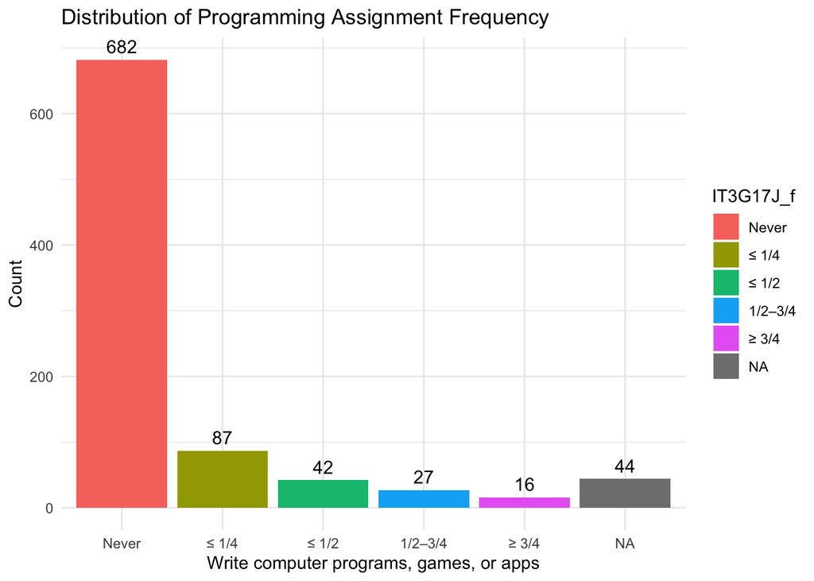

```r
teacher_clean$IT3G17J_f <- factor(
  teacher_clean$IT3G17J,
  levels = c(1,2,3,4,5),
  labels = c(
    "Never",
    "≤ 1/4",
    "≤ 1/2",
    "1/2–3/4",
    "≥ 3/4"
  )
)

ggplot(teacher_clean, aes(IT3G17J_f, fill = IT3G17J_f)) +
  geom_bar() +
  geom_text(stat = "count",
            aes(label = after_stat(count)),
            vjust = -0.5,
            size = 4)+
  theme_minimal() +
  labs(title = "Distribution of Programming Assignment Frequency",
       x = "Write computer programs, games, or apps",
       y = "Count")
```

- I collapsed the outcome variable into a binary indicator that reflecting whether the teacher ever engages students in computer programming activities. The original outcome is highly skewed toward “Never”, and the categories above “Never” are sparse. It would be risky for me to use ordinal modeling. 1: Never; 2: One quarter or less (but more than never); 3: One half or less (but more than one quarter); 4: More than one-half (but less than three quarters); 5: Three quarters or more

```r
teacher_clean <- teacher_clean %>%
  mutate(
    assign_pro_bi = ifelse(IT3G17J == 1,0,1)
  ) %>%
  select(-IT3G17J,-IT3G17J_f,-IDCNTRY,-CNTRY, -IEADATE,-IDLANG_TCQ)
```

```r
# Initial data preparation
require(finalfit)
ff_glimpse(teacher_clean)
```

```
## $Continuous
##                       label var_type   n missing_n missing_percent     mean
## IDSCHOOL           IDSCHOOL    <dbl> 898         0             0.0   5060.8
## IDTEACH             IDTEACH    <dbl> 898         0             0.0 506087.3
## IT3G01               IT3G01    <dbl> 897         1             0.1      1.3
## IT3G02               IT3G02    <dbl> 888        10             1.1     42.8
## IT3G03A             IT3G03A    <dbl> 895         3             0.3      1.8
## IT3G03B             IT3G03B    <dbl> 895         3             0.3      2.0
## IT3G03C             IT3G03C    <dbl> 895         3             0.3      1.7
## IT3G03D             IT3G03D    <dbl> 895         3             0.3      1.8
## IT3G03E             IT3G03E    <dbl> 895         3             0.3      1.8
## IT3G03F             IT3G03F    <dbl> 895         3             0.3      1.9
## IT3G03G             IT3G03G    <dbl> 895         3             0.3      2.0
## IT3G03H             IT3G03H    <dbl> 895         3             0.3      2.0
## IT3G03I             IT3G03I    <dbl> 895         3             0.3      1.8
## IT3G04               IT3G04    <dbl> 893         5             0.6      1.0
## IT3G05A             IT3G05A    <dbl> 887        11             1.2      3.4
## IT3G05B             IT3G05B    <dbl> 884        14             1.6      3.4
## IT3G05C             IT3G05C    <dbl> 883        15             1.7      3.4
## IT3G06A             IT3G06A    <dbl> 885        13             1.4      4.5
## IT3G06B             IT3G06B    <dbl> 878        20             2.2      4.5
## IT3G06C             IT3G06C    <dbl> 880        18             2.0      3.5
## IT3G06D             IT3G06D    <dbl> 879        19             2.1      3.7
## IT3G06E             IT3G06E    <dbl> 879        19             2.1      4.0
## IT3G07A             IT3G07A    <dbl> 881        17             1.9      1.4
## IT3G07B             IT3G07B    <dbl> 882        16             1.8      1.6
## IT3G07C             IT3G07C    <dbl> 877        21             2.3      1.9
## IT3G07D             IT3G07D    <dbl> 878        20             2.2      1.5
## IT3G07E             IT3G07E    <dbl> 880        18             2.0      1.3
## IT3G07F             IT3G07F    <dbl> 878        20             2.2      1.7
## IT3G07G             IT3G07G    <dbl> 882        16             1.8      1.7
## IT3G07H             IT3G07H    <dbl> 882        16             1.8      1.8
## IT3G07I             IT3G07I    <dbl> 881        17             1.9      1.5
## IT3G07J             IT3G07J    <dbl> 882        16             1.8      1.7
## IT3G07K             IT3G07K    <dbl> 882        16             1.8      1.7
## IT3G07L             IT3G07L    <dbl> 879        19             2.1      1.7
## IT3G07M             IT3G07M    <dbl> 877        21             2.3      2.1
## IT3G07N             IT3G07N    <dbl> 881        17             1.9      1.6
## IT3G08A             IT3G08A    <dbl> 876        22             2.4      1.5
## IT3G08B             IT3G08B    <dbl> 875        23             2.6      1.6
```

[output cut: 361 more lines]

```
## IT3G21J          1.0      1.0         4.0      4.0         5.0      6.0
## IT3G21K          1.1      1.0         4.0      4.0         5.0      6.0
## IT3G21L          1.1      1.0         4.0      5.0         5.0      6.0
## IT3G21M          1.1      1.0         4.0      4.0         5.0      6.0
## IT3G21N          1.0      1.0         4.0      5.0         5.0      6.0
## IT3G21O          1.0      1.0         4.0      4.0         5.0      6.0
## IT3G21P          1.1      1.0         3.0      4.0         5.0      6.0
## IT3G21Q          1.3      1.0         3.0      4.0         5.0      6.0
## IT3G21R          1.3      1.0         3.0      4.0         4.0      6.0
## SUBJDOMAIN       1.1      1.0         2.0      3.0         4.0      4.0
## TGENDER          0.5      1.0         1.0      1.0         2.0      2.0
## assign_pro_bi    0.4      0.0         0.0      0.0         0.0      1.0
##
## $Categorical
## data frame with 0 columns and 898 rows
```

```r
require(dplyr)

# identify variables
categorical_vars <- teacher_clean %>%
  summarise(across(everything(), ~n_distinct(.x, na.rm = TRUE))) %>%
  pivot_longer(everything(), names_to = "variable", values_to = "unique_n") %>%
  filter(unique_n <= 10 |
           sapply(teacher_clean, is.character)[match(variable, names(teacher_clean))]) %>%
  pull(variable)



# Move IDSCHOOL to categorical_var
teacher_clean$IDSCHOOL <- as.factor(teacher_clean$IDSCHOOL)
categorical_vars <- c(categorical_vars, "IDSCHOOL") %>%
  unique()

continuous_vars <- setdiff(names(teacher_clean), categorical_vars)
```

```r
# Convert all categorical variables to factors
teacher_clean <- teacher_clean %>%
  mutate(across(all_of(categorical_vars), as.factor))
```

Missing summary table

```r
missing_ <- ff_glimpse(teacher_clean)$Categorical
head(arrange(missing_, desc(missing_percent)))
```

```
##             label var_type   n missing_n missing_percent levels_n
## IT3G16BN IT3G16BN    <fct> 291       607            67.6        4
## IT3G16BO IT3G16BO    <fct> 295       603            67.1        4
## IT3G16AL IT3G16AL    <fct> 845        53             5.9        4
## IT3G21Q   IT3G21Q    <fct> 845        53             5.9        6
## IT3G21R   IT3G21R    <fct> 845        53             5.9        6
## IT3G21O   IT3G21O    <fct> 846        52             5.8        6
##                                   levels          levels_count
## IT3G16BN "1", "2", "3", "4", "(Missing)"  59, 118, 74, 40, 607
## IT3G16BO "1", "2", "3", "4", "(Missing)"  43, 120, 88, 44, 603
## IT3G16AL "1", "2", "3", "4", "(Missing)" 127, 432, 197, 89, 53
## IT3G21Q                                -                     -
## IT3G21R                                -                     -
## IT3G21O                                -                     -
##                        levels_percent
## IT3G16BN  6.6, 13.1,  8.2,  4.5, 67.6
## IT3G16BO  4.8, 13.4,  9.8,  4.9, 67.1
## IT3G16AL 14.1, 48.1, 21.9,  9.9,  5.9
## IT3G21Q                             -
## IT3G21R                             -
## IT3G21O                             -
```

### 1.1 Group variables into different types

```r
outcome <- c('assign_pro_bi')

id      <- c("IDTEACH")

categorical <- setdiff(categorical_vars, outcome)

teacher_clean <- teacher_clean %>%
  mutate(across(all_of(categorical), as.factor))

teacher_clean$assign_pro_bi <- factor(teacher_clean$assign_pro_bi,
                                      levels = c(0,1),
                                      labels = c("Never","AnyUse"))

continuous <- setdiff(continuous_vars,id)
```

Build blueprint recipes to prepare data: I implemented the following steps:

### 1.2 Prepare a recipe

```r
require(recipes)
options(warn=-1)

blueprint <- recipe(assign_pro_bi ~ ., data =  teacher_clean) %>%
  #update_role(assign_pro_bi, new_role = "outcome") %>%
  update_role(IDTEACH, new_role = "ID") %>%

  # For all 203 predictors, create an indicator variable for missingness

  step_indicate_na(all_predictors()) %>%

  # Remove the variable with zero variance, this will also remove
  # The missingness variables

  step_zv(all_predictors()) %>%

  # impute the missing values using mean and mode

  step_impute_mean(all_of(continuous)) %>%
  step_impute_mode(all_of(categorical)) %>%

  # 2nd degree polynomial terms for continuous variables

  step_poly(all_of(continuous),degree = 2) %>%

  # Standardize the polynomial terms of continuous variables

  step_normalize(all_numeric_predictors()) %>%

  # One-hot encoding for all categorical variables

  step_dummy(all_nominal_predictors(), one_hot = TRUE)

 #step_num2factor(assign_pro_bi,
                  #transform = function(x)x + 1,
                  #levels = c("Never","AnyUse"))

blueprint
```

```
## ── Recipe ──────────────────────────────────────────────────────────────────────
```

```
## ── Inputs
```

```
## Number of variables by role
```

```
## outcome:     1
## predictor: 203
## ID:          1
```

```
## ── Operations
```

```
## • Creating missing data variable indicators for: all_predictors()
```

```
## • Zero variance filter on: all_predictors()
```

```
## • Mean imputation for: all_of(continuous)
```

```
## • Mode imputation for: all_of(categorical)
```

```
## • Polynomial expansion on: all_of(continuous)
```

```
## • Centering and scaling for: all_numeric_predictors()
```

```
## • Dummy variables from: all_nominal_predictors()
```

### 1.3 Train/Test data split

```r
require(caret)
teacher_clean <- teacher_clean %>%
  filter(!is.na(assign_pro_bi))

loc <- sample(1:nrow(teacher_clean), round(nrow(teacher_clean)*0.8))

teacher_tr <- teacher_clean[loc, ]
teacher_te <- teacher_clean[-loc, ]

dim(teacher_tr)
```

```
## [1] 683 205
```

```r
dim(teacher_te)
```

```
## [1] 171 205
```

## 2. Building a Logistic Regression Model with No Regularization

```r
# Randomly shuffle the training dataset
set.seed(11252025)
teacher_tr = teacher_tr[sample(nrow(teacher_tr)), ]

# Create 10 folds with equal size
folds = cut(seq(1,nrow(teacher_tr)), breaks = 10, labels = FALSE)

# Create the list for each fold
my.indices <- vector('list', 10)

for (i in 1:10){
  my.indices[[i]] <- which(folds != i)
}
```

```r
cv <- trainControl(
  method    = "cv",
  index     = my.indices,
  classProbs = TRUE,
  summaryFunction = mnLogLoss,
  savePredictions = "final" # confirm positive class
)
```

### 2.1 Train the logistic regression model

```r
caret <- train(blueprint,
                   data   = teacher_tr,
                   method = "glm",
                   family = "binomial",
                   metric = "logLoss",
                   trControl = cv)

caret
```

```
## Generalized Linear Model
##
## 683 samples
## 204 predictors
##   2 classes: 'Never', 'AnyUse'
##
## Recipe steps: indicate_na, zv, impute_mean, impute_mode, poly, normalize, dummy
## Resampling: Cross-Validated (10 fold)
## Summary of sample sizes: 614, 615, 615, 615, 614, 615, ...
## Resampling results:
##
##   logLoss
##   16.87844
```

```r
LL_mod <- caret$results$logLoss
```

### 2.2 Logistic Regression Performance Evaluation

```r
predicted_te <- predict(caret, teacher_te, type = 'prob')
dim(predicted_te)
```

```
## [1] 171   2
```

```r
head(predicted_te)
```

```
##          Never       AnyUse
## 1 2.220446e-16 1.000000e+00
## 2 1.000000e+00 2.220446e-16
## 3 2.220446e-16 1.000000e+00
## 4 1.000000e+00 2.220446e-16
## 5 1.000000e+00 2.220446e-16
## 6 1.000000e+00 2.220446e-16
```

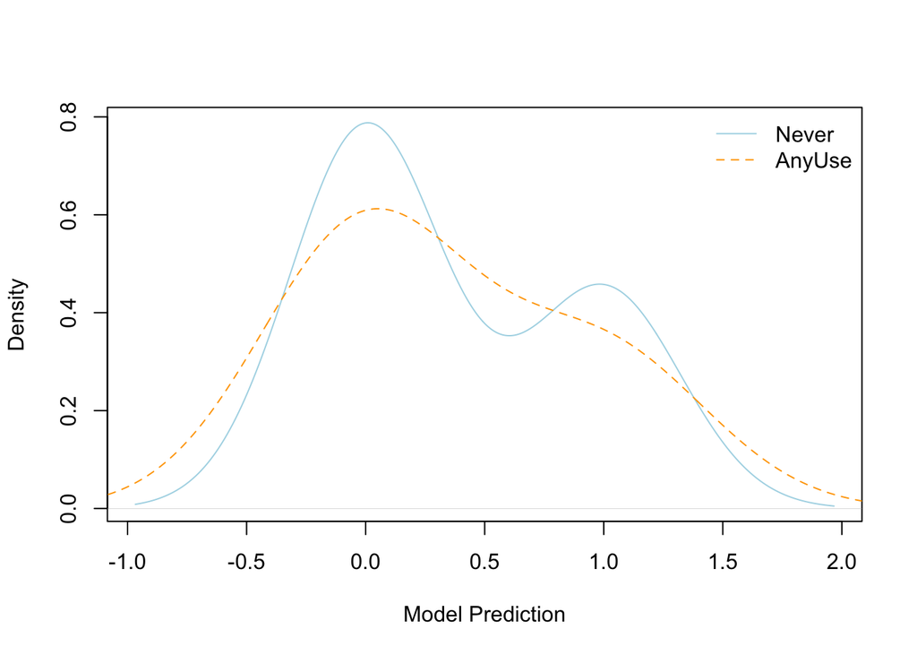

```r
group_0 <- which(teacher_te$assign_pro_bi=="Never")
group_1 <- which(teacher_te$assign_pro_bi=="AnyUse")

prob_0 <- jitter(predicted_te$AnyUse[group_0], amount=1e-4)
prob_1 <- jitter(predicted_te$AnyUse[group_1], amount=1e-4)

plot(density(prob_0, adjust=2), col = "lightblue", xlab='Model Prediction', main = "")
lines(density(prob_1, adjust=2),col = "orange",lty=2)
legend("topright", c("Never","AnyUse"), col = c("lightblue","orange"), lty=c(1,2), bty='n')
```

```r
require(cutpointr)
cut.obj <- cutpointr(x = predicted_te$AnyUse,
                     class = teacher_te$assign_pro_bi)
```

```
## Assuming the positive class is AnyUse
```

```
## Assuming the positive class has higher x values
```

```
## Multiple optimal cutpoints found, applying break_ties.
```

```r
cut.obj
```

```
## # A tibble: 1 × 16
##   direction optimal_cutpoint method          sum_sens_spec      acc sensitivity
##   <chr>                <dbl> <chr>                   <dbl>    <dbl>       <dbl>
## 1 >=                     Inf maximize_metric             1 0.818713           0
##   specificity      AUC pos_class neg_class prevalence outcome predictor
##         <dbl>    <dbl> <fct>     <fct>          <dbl> <chr>   <chr>
## 1           1 0.476267 AnyUse    Never       0.181287 class   x
##   data               roc_curve            boot
##   <list>             <list>               <lgl>
## 1 <tibble [171 × 2]> <rc_ctpnt [23 × 10]> NA
```

```r
AUC <- auc(cut.obj)
```

```r
# Confusion matrix assuming the threshold is 0.5

pred_class <- ifelse(predicted_te$AnyUse>.5,1,0)

confusion <- table(teacher_te$assign_pro_bi,pred_class)

confusion
```

```
##         pred_class
##           0  1
##   Never  89 51
##   AnyUse 20 11
```

```r
# True Negative Rate
TNR <- confusion[1,1]/(confusion[1,1]+confusion[1,2])

# False Positive Rate
FPR <- confusion[1,2]/(confusion[1,1]+confusion[1,2])

# True Positive Rate
TPR <- confusion[2,2]/(confusion[2,1]+confusion[2,2])

# Precision
PRE <- confusion[2,2]/(confusion[1,2]+confusion[2,2])

# overall acuracy
ACC <- (confusion[2,2]+confusion[1,1])/(confusion[2,2]+confusion[1,1]+confusion[1,2]+confusion[2,1])
```

## 3. Building a Classification Model with Ridge Penalty

```r
grid_ridge <- data.frame(alpha = 0, lambda = c(seq(0,.001,.00001),.005,.01,.05,.1)) # bench mark values
head(grid_ridge)
```

```
##   alpha lambda
## 1     0  0e+00
## 2     0  1e-05
## 3     0  2e-05
## 4     0  3e-05
## 5     0  4e-05
## 6     0  5e-05
```

### 3.1 Train the logistic regression model

```r
Sys.time()
```

```
## [1] "2025-12-03 17:28:52 PST"
```

```r
caret_ridge <- train(blueprint,
                     data      = teacher_tr,
                     method    = "glmnet",
                     family    = "binomial",
                     metric    = "logLoss",
                     trControl = cv,
                     tuneGrid = grid_ridge)
Sys.time()
```

```
## [1] "2025-12-03 17:29:00 PST"
```

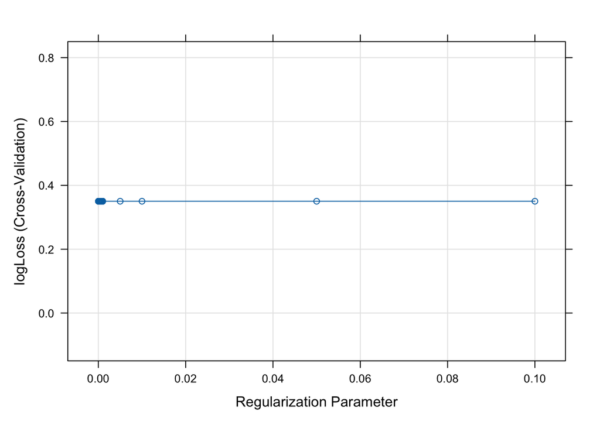

```r
plot(caret_ridge)
```

```r
# Optimal lambda ridge penalty
LL_ridge <- caret_ridge$bestTune$lambda
```

### 3.2 Logistic Regression Performance Evaluation

```r
# Performance Evaluation
predicted_ridge_te <- predict(caret_ridge, teacher_te, type = 'prob')
dim(predicted_ridge_te)
```

```
## [1] 171   2
```

```r
head(predicted_ridge_te)
```

```
##       Never     AnyUse
## 1 0.8813734 0.11862663
## 2 0.9293149 0.07068509
## 3 0.9417231 0.05827688
## 4 0.6599880 0.34001198
## 5 0.8727797 0.12722034
## 6 0.9116370 0.08836296
```

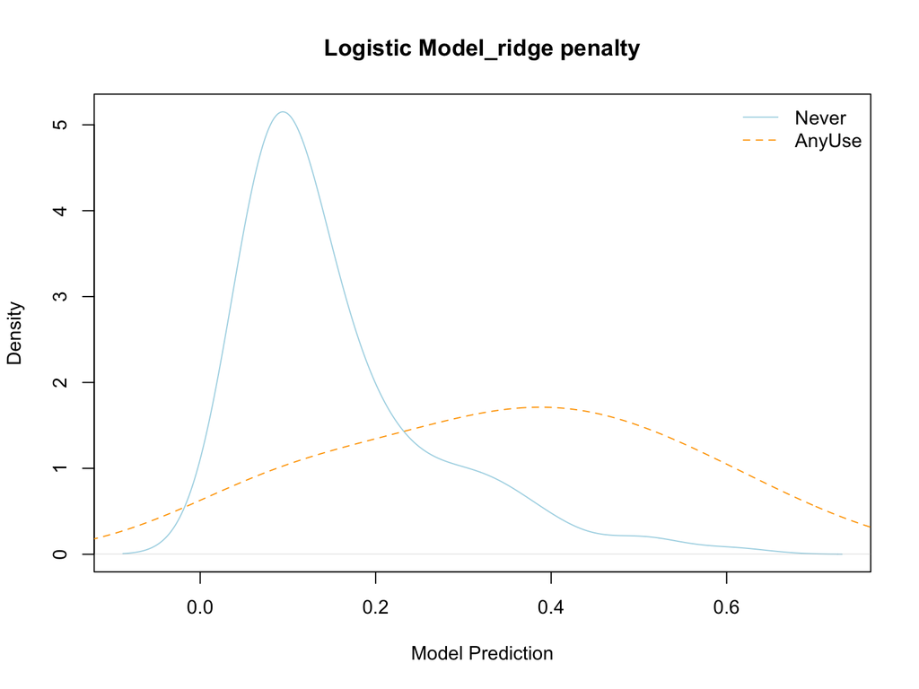

```r
# Check the separation of distribution for the
# predicted probabilities between the two classes

plot(density(predicted_ridge_te[group_0,]$AnyUse, adjust = 1.5),col = "lightblue",xlab = 'Model Prediction', main = "Logistic Model_ridge penalty")
points(density(predicted_ridge_te[group_1,]$AnyUse, adjust = 1.5),col = "orange",lty=2,type='l')

legend("topright", c("Never","AnyUse"),col = c("lightblue","orange"),lty=c(1,2), bty='n')
```

```r
cut.obj_ridge <- cutpointr(x = predicted_ridge_te$AnyUse,
                           class = teacher_te$assign_pro_bi)
```

```
## Assuming the positive class is AnyUse
```

```
## Assuming the positive class has higher x values
```

```r
AUC_ridge <- auc(cut.obj_ridge)
```

```r
pred_ridge_class <- ifelse(predicted_ridge_te$AnyUse>.5,1,0)
confusion_ridge <- table(teacher_te$assign_pro_bi, pred_ridge_class)
confusion_ridge
```

```
##         pred_ridge_class
##            0   1
##   Never  137   3
##   AnyUse  24   7
```

```r
# True Negative Rate
TNR_ridge <- confusion_ridge[1,1]/(confusion_ridge[1,1]+confusion_ridge[1,2])

# False Positive Rate
FPR_ridge <- confusion_ridge[1,2]/(confusion_ridge[1,1]+confusion_ridge[1,2])

# True Positive Rate
TPR_ridge <- confusion_ridge[2,2]/(confusion_ridge[2,1]+confusion_ridge[2,2])

# Precision
PRE_ridge <- confusion_ridge[2,2]/(confusion_ridge[1,2]+confusion_ridge[2,2])

# overall acuracy
ACC_ridge <- (confusion_ridge[2,2]+confusion_ridge[1,1])/(confusion_ridge[2,2]+confusion_ridge[1,1]+confusion_ridge[1,2]+confusion_ridge[2,1])
```

Using Classification with Ridge Penalty to explore the most important 10 variables correlates with our outcome variable

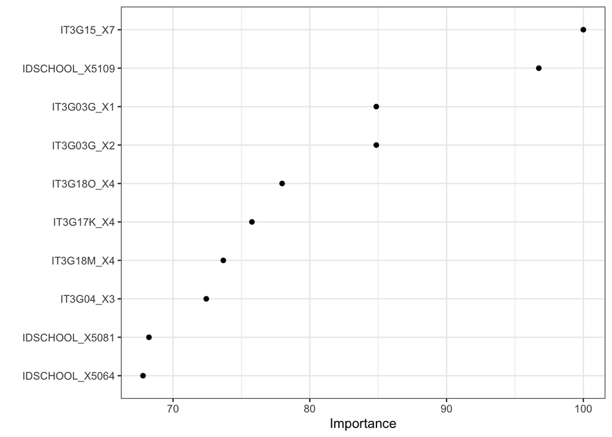

```r
require(vip)
vip(caret_ridge, num_features = 10, geom = "point") + theme_bw()
```

## 4. Building a Classification Model with Lasso Penalty

```r
grid_lasso <- data.frame(alpha = 1, lambda = seq(0, .001,.00001))
head(grid_lasso)
```

```
##   alpha lambda
## 1     1  0e+00
## 2     1  1e-05
## 3     1  2e-05
## 4     1  3e-05
## 5     1  4e-05
## 6     1  5e-05
```

```r
Sys.time()
```

```
## [1] "2025-12-03 17:29:01 PST"
```

```r
caret_lasso <- train(blueprint,
                     data = teacher_tr,
                     method = "glmnet",
                     family = "binomial",
                     metric = "logLoss",
                     trControl = cv,
                     tuneGrid = grid_lasso)

Sys.time()
```

```
## [1] "2025-12-03 17:29:07 PST"
```

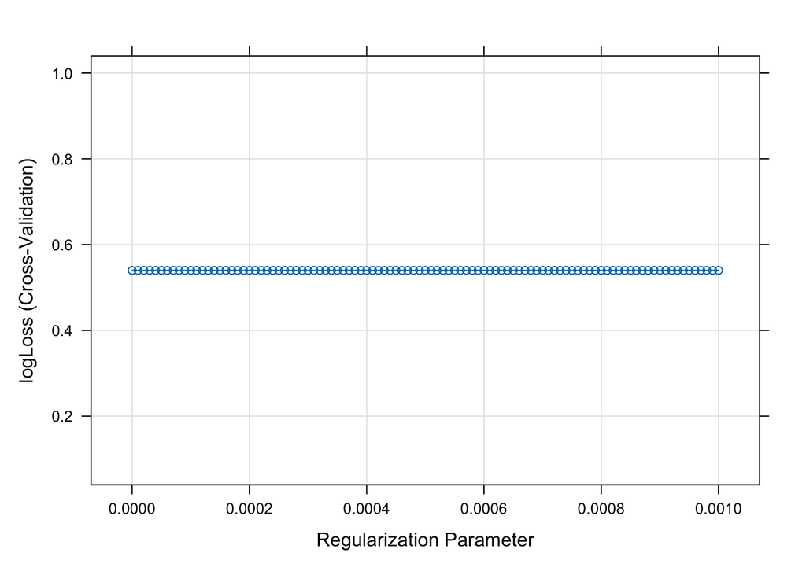

```r
plot(caret_lasso)
```

```r
LL_lasso <- caret_lasso$bestTune$lambda
```

```r
predicted_lasso_te <- predict(caret_lasso, teacher_te, type = "prob")
dim(predicted_lasso_te)
```

```
## [1] 171   2
```

```r
head(predicted_lasso_te)
```

```
##       Never      AnyUse
## 1 0.8018099 0.198190064
## 2 0.9961859 0.003814129
## 3 0.9991541 0.000845911
## 4 0.7695237 0.230476312
## 5 0.9902626 0.009737417
## 6 0.9918344 0.008165613
```

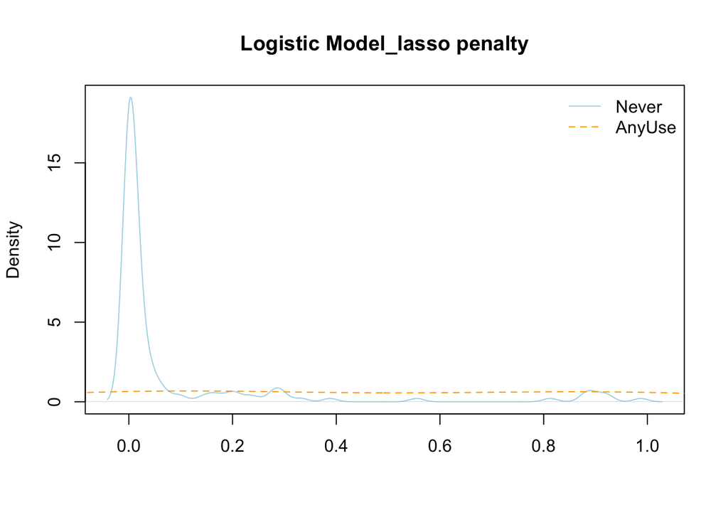

```r
plot(density(predicted_lasso_te[group_0,]$AnyUse,adjust=1.5), col="lightblue",xlab = '', main = 'Logistic Model_lasso penalty')
points(density(predicted_lasso_te[group_1,]$AnyUse,adjust=1.5),col="orange",lty=2,type='l')
legend("topright", c("Never","AnyUse"), col = c("lightblue","orange"), lty=c(1,2), bty='n')
```

```r
cut.obj_lasso <- cutpointr(x = predicted_lasso_te$AnyUse,
                           class = teacher_te$assign_pro_bi)
```

```
## Assuming the positive class is AnyUse
```

```
## Assuming the positive class has higher x values
```

```r
AUC_lasso <- auc(cut.obj_lasso)
```

```r
pred_lasso_class <- ifelse(predicted_lasso_te$AnyUse>.5,1,0)
confusion_lasso <- table(teacher_te$assign_pro_bi,pred_lasso_class)
confusion_lasso
```

```
##         pred_lasso_class
##            0   1
##   Never  131   9
##   AnyUse  16  15
```

```r
# True Negative Rate
TNR_lasso <- confusion_lasso [1,1]/(confusion_lasso[1,1]+confusion_lasso[1,2])

# False Positive Rate
FPR_lasso <- confusion_lasso[1,2]/(confusion_lasso[1,1]+confusion_lasso[1,2])

# True Positive Rate
TPR_lasso <- confusion_lasso[2,2]/(confusion_lasso[2,1]+confusion_lasso[2,2])

# Precision
PRE_lasso <- confusion_lasso[2,2]/(confusion_lasso[1,2]+confusion_lasso[2,2])

# overall accuracy
ACC_lasso <- (confusion_lasso[2,2]+confusion_lasso[1,1])/(confusion_lasso[2,2]+confusion_lasso[1,1]+confusion_lasso[1,2]+confusion_lasso[2,1])
```

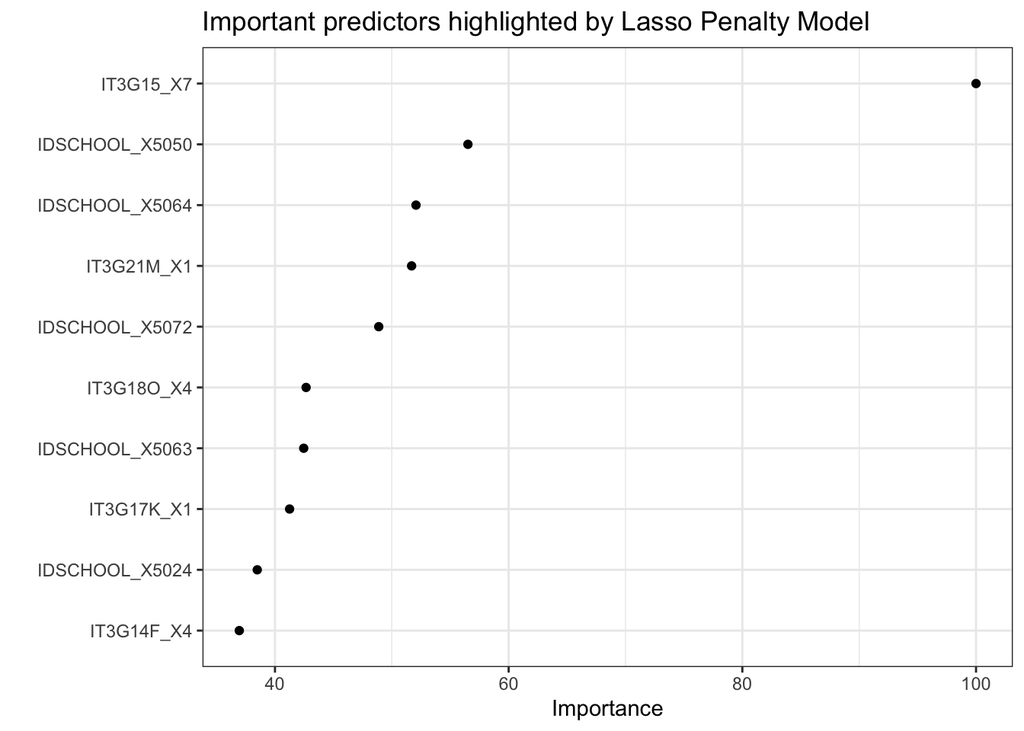

```r
vip(caret_lasso, num_features = 10, geom = "point") + theme_bw()+labs(title = "Important predictors highlighted by Lasso Penalty Model")
```

```r
coefs_lasso <- coef(caret_lasso$finalModel,
                    caret_lasso$bestTune$lambda)

ind_lasso <- order(abs(coefs_lasso[,1]),decreasing=T)

head(as.matrix(coefs_lasso[ind_lasso,]),10)
```

```
##                     [,1]
## IT3G15_X7       6.622315
## IDSCHOOL_X5050  3.742482
## IDSCHOOL_X5064 -3.448216
## IT3G21M_X1      3.423260
## IDSCHOOL_X5072  3.237076
## IT3G18O_X4      2.825295
## IDSCHOOL_X5063 -2.811755
## IT3G17K_X1     -2.731729
## IDSCHOOL_X5024 -2.548441
## IT3G14F_X4     -2.446648
```

## Report

```r
results <- data.frame(
    Model    = c("Logistic Regression","Logistic Regression with Ridge Penalty","Logistic Regression with Lasso Penalty"),
    LL       = c(LL_mod,LL_ridge,LL_lasso),
    AUC      = c(AUC,AUC_ridge,AUC_lasso),
    ACC      = c(ACC,ACC_ridge,ACC_lasso),
    TPR      = c(TPR,TPR_ridge,TPR_lasso),
    TNR      = c(TNR,TNR_ridge,TNR_lasso),
    PRE      = c(PRE,PRE_ridge,PRE_lasso)
)

knitr::kable(results,digits = 3)
```

[output not shown]